# Assembling an R Visualization Presentation

# Average number of reviews by genre

We can observe that Fiction books have a higher average number of reviews than Non fiction ones. It should be really interesting to know if these reviews are good or bad, because this could help us to analyze if people tend to do more reviews for Fiction books because:

They don’t like it and they want to expose their opinion publicly. People who read Fiction books are more active online and are more likely to do reviews.

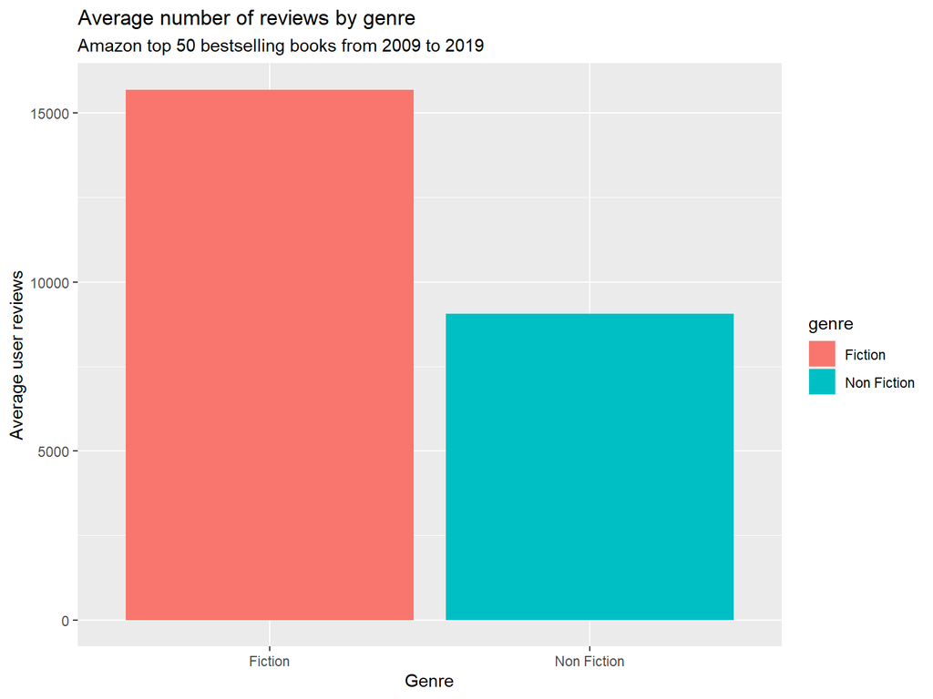

# User rating vs number of reviews

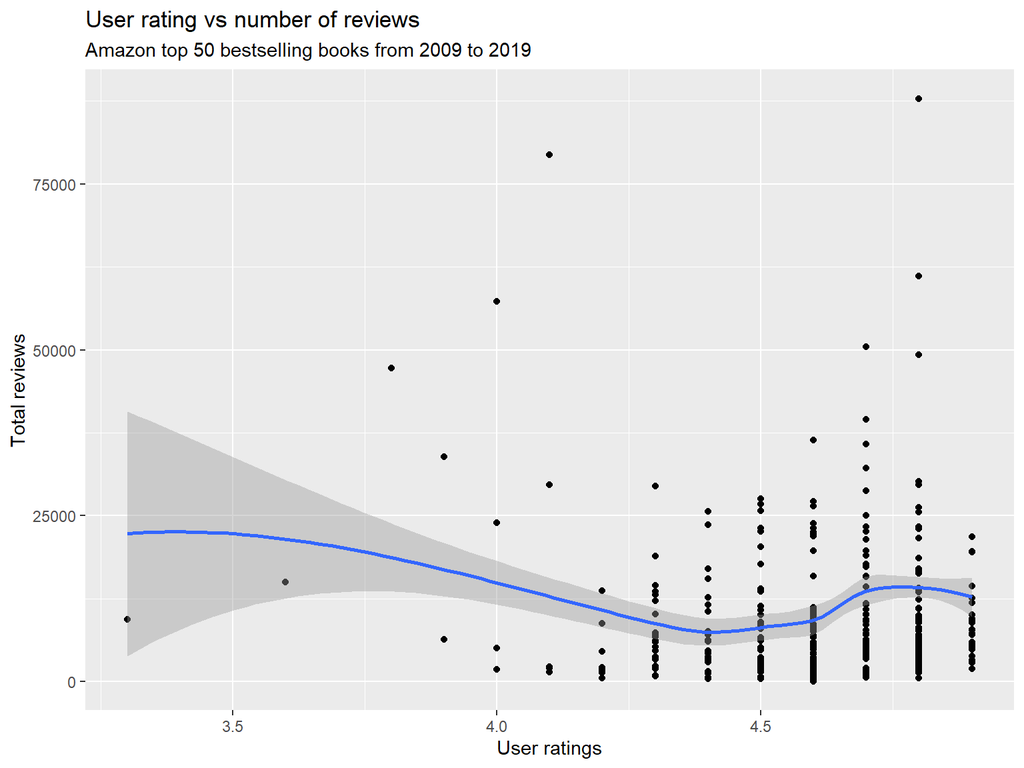

# Conclusion

As a buyer wanting to buy books from Amazon, the data visualization makes it easier for the buyer to decide whether to buy a book based on its rating, reviews, or the greatest writers that did well between 2009 and 2019. To summarize, data visualization assists in making rapid decisions when given with graphs that are easy to read and comprehend.